# SGWT Analysis with Simulation Patterns

BioGSP Package

2025-09-26

# Introduction

This vignette demonstrates the use of Spectral Graph Wavelet Transform (SGWT) analysis using the BioGSP package with two types of simulated spatial patterns:

1. **Multiple Center Patterns**: Concentric circles with inner and outer rings at different scales
2. **Concentric Ring Patterns**: Dynamic ring patterns with moving outer boundaries

The package now supports flexible column naming, allowing you to use any column names for spatial coordinates (X, Y) and signals (signal_1, signal_2).

# Load Required Libraries

```r
# Load required packages
library(ggplot2)
library(patchwork)
library(dplyr)
library(viridis)
library(Matrix)
library(igraph)
library(RANN)
library(RSpectra)
library(ggpubr)

# Load BioGSP functions directly
source('../R/simulation.R')
source('../R/sgwt_core.R')
source('../R/sgwt_main.R')
source('../R/utilities.R')
source('../R/visualization.R')

# Set random seed for reproducibility
set.seed(123)
```

# Part 1: Multiple Center Simulation

## Generate Multiple Center Patterns

First, let’s generate spatial patterns with multiple circular centers at different scales.

```r
# Define parameter sequences
Ra_seq <- seq(from = 10, to = 3, length.out = 4)   # Inner circle radii
Rb_seq <- seq(from = 15, to = 5, length.out = 4)   # Outer ring radii

# Generate simulation data
multicenter_data <- simulate_multiscale(
  grid_size = 50,
  n_centers = 3,
  Ra_seq = Ra_seq,
  Rb_seq = Rb_seq,
  seed = 123
)

# Display the structure of generated data
cat("Generated", length(multicenter_data), "different pattern combinations\n")
```

```
## Generated 16 different pattern combinations
```

```r
cat("Data structure for first pattern:\n")
```

```
## Data structure for first pattern:
```

```r
str(multicenter_data[[1]])
```

```
## 'data.frame':    2500 obs. of  4 variables:
##  $ X       : int  1 2 3 4 5 6 7 8 9 10 ...
##  $ Y       : int  1 1 1 1 1 1 1 1 1 1 ...
##  $ signal_1: num  0 0 0 0 0 0 0 0 0 0 ...
##  $ signal_2: num  1 1 1 1 1 1 1 1 1 1 ...
```

## Visualize Multiple Center Patterns

```r
# Create visualization of all pattern combinations
multicenter_plot <- visualize_multiscale(
  sim_data = multicenter_data,
  Ra_seq = Ra_seq,
  Rb_seq = Rb_seq,
  bg_color = "grey",
  signal1_color = "#16964a",
  signal2_color = "#2958a8"
)
```

```
##
## Background   signal_1   signal_2
##        208        832       1460
##
## Background   signal_1   signal_2
##        348        533       1619
##
## Background   signal_1   signal_2
##        529        267       1704
##
## Background   signal_1   signal_2
##        777         87       1636
##
## Background   signal_1   signal_2
##        424        832       1244
##
## Background   signal_1   signal_2
##        618        533       1349
##
## Background   signal_1   signal_2
##        881        267       1352
##
## Background   signal_1   signal_2
##       1125         87       1288
##
## Background   signal_1   signal_2
##        727        832        941
##
## Background   signal_1   signal_2
##        993        533        974
##
## Background   signal_1   signal_2
##       1225        267       1008
##
## Background   signal_1   signal_2
##       1501         87        912
##
## Background   signal_1   signal_2
##       1087        832        581
##
## Background   signal_1   signal_2
##       1345        533        622
##
## Background   signal_1   signal_2
##       1618        267        615
##
## Background   signal_1   signal_2
##       1935         87        478
```

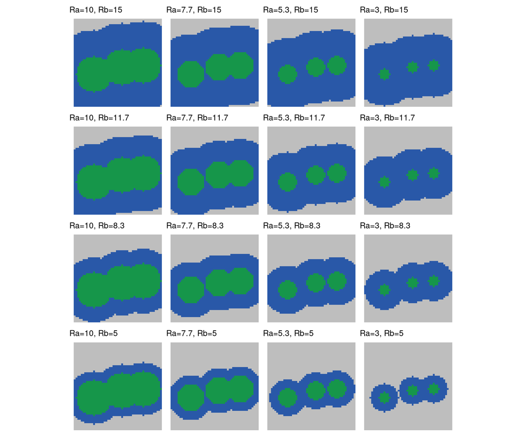

```r
print(multicenter_plot)
```

## SGWT Analysis on Multiple Center Data

Let’s perform SGWT analysis on one of the generated patterns.

```r
# Select a specific pattern for analysis
selected_pattern <- multicenter_data[["simulated_Ra_3_Rb_8.33333333333333"]]

# Perform SGWT analysis on signal_1 (inner circles)
sgwt_result_signal1 <- SGWT(
  data.in = selected_pattern,
  x_col = "X",
  y_col = "Y",
  signal = "signal_1",
  k = 15,
  J = 4,
  scaling_factor = 2,
  kernel_type = "mexican_hat",
  k_fold = 8
)
```

```
## Building graph from spatial coordinates...
## Computing Laplacian and eigendecomposition...
## Auto-generated scales: 0.8474, 0.4237, 0.2119, 0.1059
## Performing SGWT decomposition...
## Reconstruction RMSE: 0.113051
```

```r
cat("SGWT Analysis Results for Signal 1 (Inner Circles):\n")
```

```
## SGWT Analysis Results for Signal 1 (Inner Circles):
```

```r
cat("Reconstruction RMSE:", sgwt_result_signal1$reconstruction_error, "\n")
```

```
## Reconstruction RMSE: 0.1130514
```

```r
cat("Number of scales:", length(sgwt_result_signal1$decomposition$scales), "\n")
```

```
## Number of scales: 4
```

```r
cat("Scales:", paste(round(sgwt_result_signal1$decomposition$scales, 4), collapse = ", "), "\n")
```

```
## Scales: 0.8474, 0.4237, 0.2119, 0.1059
```

## Visualize SGWT Decomposition Results

```
## $`1`
```

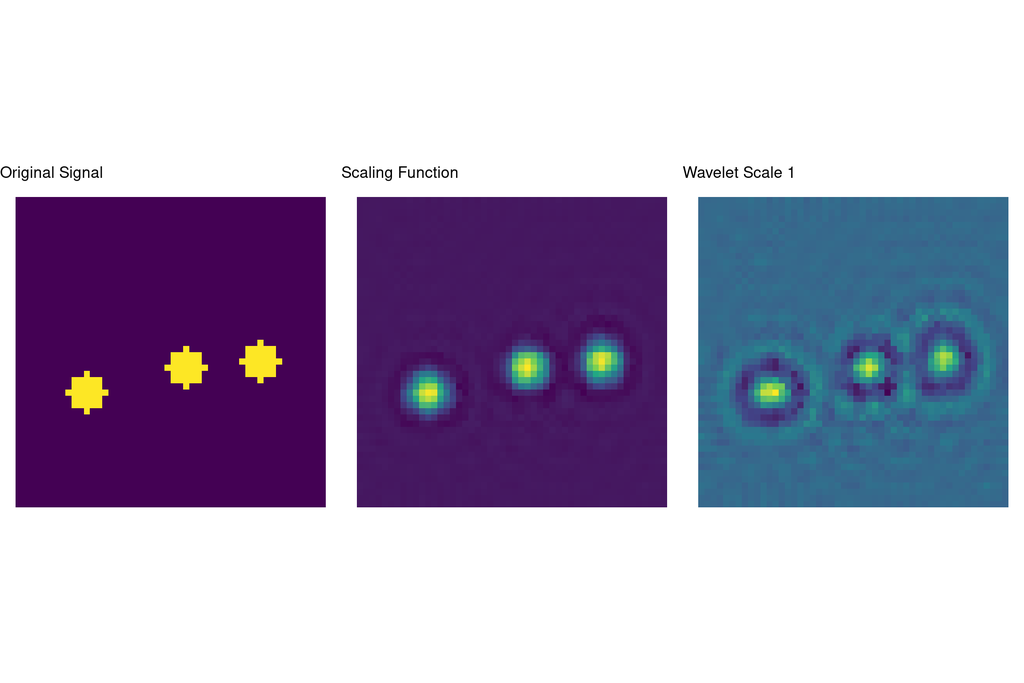

```
##
## $`2`
```

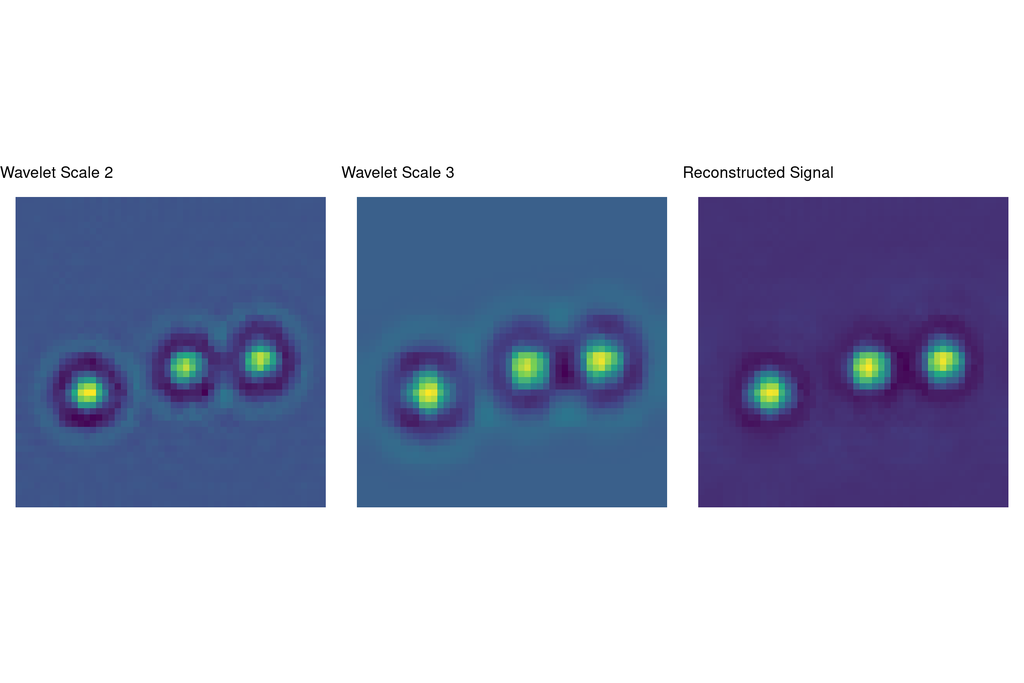

```
##
## attr(,"class")
## [1] "list"      "ggarrange"
```

```r
# Plot SGWT decomposition results
sgwt_plots <- plot_sgwt_decomposition(
  sgwt_result = sgwt_result_signal1,
  data.in = selected_pattern,
  x_col = "X",
  y_col = "Y",
  plot_scales = 1:3,
  ncol = 3
)

print(sgwt_plots)
```

## Energy Analysis

```r
# Analyze energy distribution across scales
energy_analysis <- sgwt_energy_analysis(sgwt_result_signal1)
print(energy_analysis)
```

```
##                   scale    energy energy_ratio scale_value
## scaling         scaling 66.430096   0.65902117   0.8474286
## wavelet_scale_1 scale_1  1.122786   0.01113862   0.8474286
## wavelet_scale_2 scale_2  6.241314   0.06191709   0.4237143
## wavelet_scale_3 scale_3 13.778233   0.13668725   0.2118571
## wavelet_scale_4 scale_4 13.228727   0.13123587   0.1059286
```

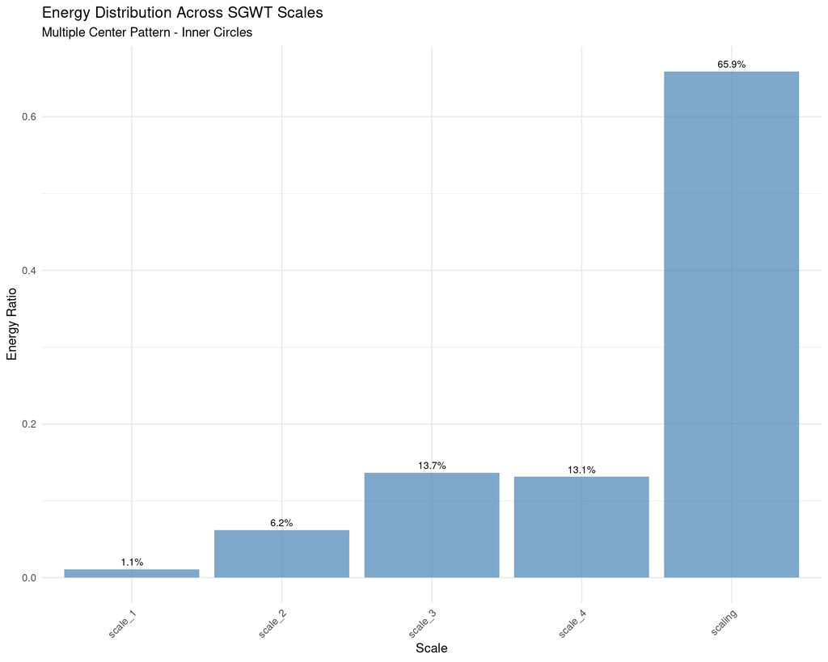

```r
# Create energy distribution plot
energy_plot <- ggplot(energy_analysis, aes(x = scale, y = energy_ratio)) +
  geom_bar(stat = "identity", fill = "steelblue", alpha = 0.7) +
  geom_text(aes(label = paste0(round(energy_ratio * 100, 1), "%")),
            vjust = -0.5, size = 3) +
  labs(title = "Energy Distribution Across SGWT Scales",
       subtitle = "Multiple Center Pattern - Inner Circles",
       x = "Scale", y = "Energy Ratio") +
  theme_minimal() +
  theme(axis.text.x = element_text(angle = 45, hjust = 1))

print(energy_plot)
```

# Part 2: Concentric Ring Simulation

## Generate Concentric Ring Patterns

Now let’s generate concentric ring patterns with dynamic outer boundaries.

```r
# Define radius sequence for inner circles
radius_seq <- seq(5, 15, by = 5)

# Generate concentric ring simulation data
ring_data <- simulate_ringpattern(
  grid_size = 60,
  radius_seq = radius_seq,
  n_movements = 6
)

# Display the structure of generated data
cat("Generated", length(ring_data), "different radius patterns\n")
```

```
## Generated 3 different radius patterns
```

```r
cat("Data structure for first pattern:\n")
```

```
## Data structure for first pattern:
```

```r
str(ring_data[[1]][1:10, ])  # Show first 10 rows
```

```
## 'data.frame':    10 obs. of  8 variables:
##  $ X            : int  1 2 3 4 5 6 7 8 9 10
##  $ Y            : int  1 1 1 1 1 1 1 1 1 1
##  $ signal_1     : num  0 0 0 0 0 0 0 0 0 0
##  $ signal_2     : num  0 0 1 1 1 1 1 1 1 1
##  $ movement     : chr  "Movement 1" "Movement 1" "Movement 1" "Movement 1" ...
##  $ movement_step: int  1 1 1 1 1 1 1 1 1 1
##  $ radius       : num  5 5 5 5 5 5 5 5 5 5
##  $ outer_radius : num  40 40 40 40 40 40 40 40 40 40
```

## Visualize Concentric Ring Patterns

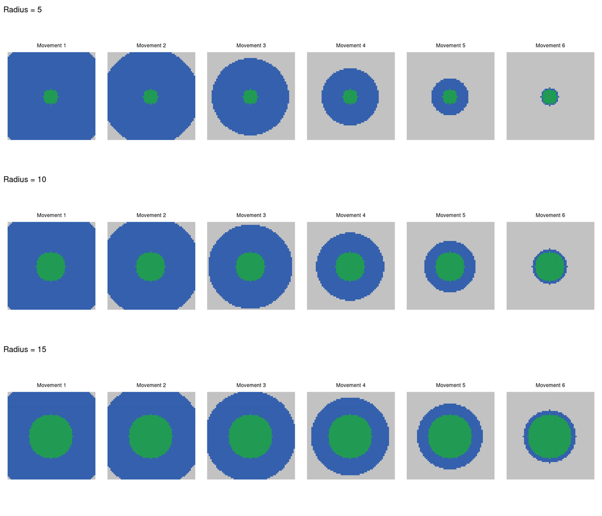

```r
# Create visualization of ring patterns
ring_plot <- visualize_ringpattern(
  sim_data = ring_data,
  radius_seq = radius_seq,
  bg_color = "grey",
  signal1_color = "#16964a",
  signal2_color = "#2958a8"
)

print(ring_plot)
```

## SGWT Analysis on Ring Data

Let’s analyze the dynamic ring patterns using SGWT.

```r
# Select a specific radius and movement for analysis
selected_ring_data <- ring_data[["radius_10"]]
# Filter to a specific movement step
movement_3_data <- selected_ring_data[selected_ring_data$movement_step == 3, ]

# Perform SGWT analysis on signal_2 (dynamic rings)
sgwt_result_rings <- SGWT(
  data.in = movement_3_data,
  x_col = "X",
  y_col = "Y",
  signal = "signal_2",
  k = 12,
  J = 4,
  scaling_factor = 2,
  kernel_type = "meyer",
  k_fold = 8
)
```

```
## Building graph from spatial coordinates...
## Computing Laplacian and eigendecomposition...
## Auto-generated scales: 0.6704, 0.3352, 0.1676, 0.0838
## Performing SGWT decomposition...
## Reconstruction RMSE: 0.241607
```

```r
cat("SGWT Analysis Results for Ring Pattern:\n")
```

```
## SGWT Analysis Results for Ring Pattern:
```

```r
cat("Reconstruction RMSE:", sgwt_result_rings$reconstruction_error, "\n")
```

```
## Reconstruction RMSE: 0.2416072
```

```r
cat("Number of scales:", length(sgwt_result_rings$decomposition$scales), "\n")
```

```
## Number of scales: 4
```

```r
cat("Scales:", paste(round(sgwt_result_rings$decomposition$scales, 4), collapse = ", "), "\n")
```

```
## Scales: 0.6704, 0.3352, 0.1676, 0.0838
```

## Visualize Ring SGWT Results

```
## $`1`
```

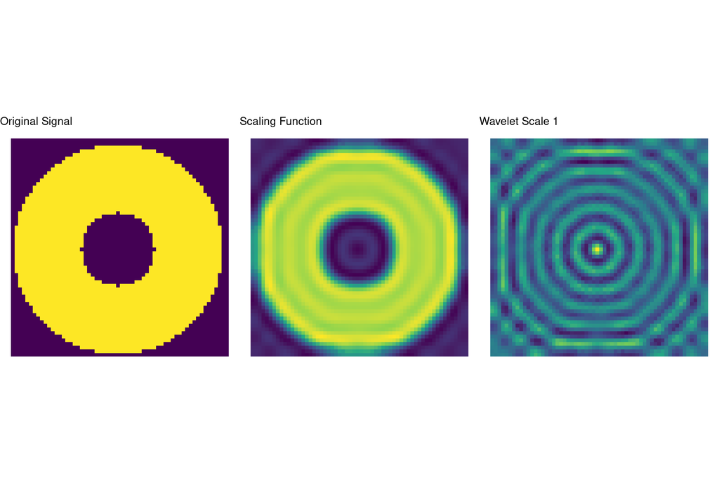

```
##
## $`2`
```

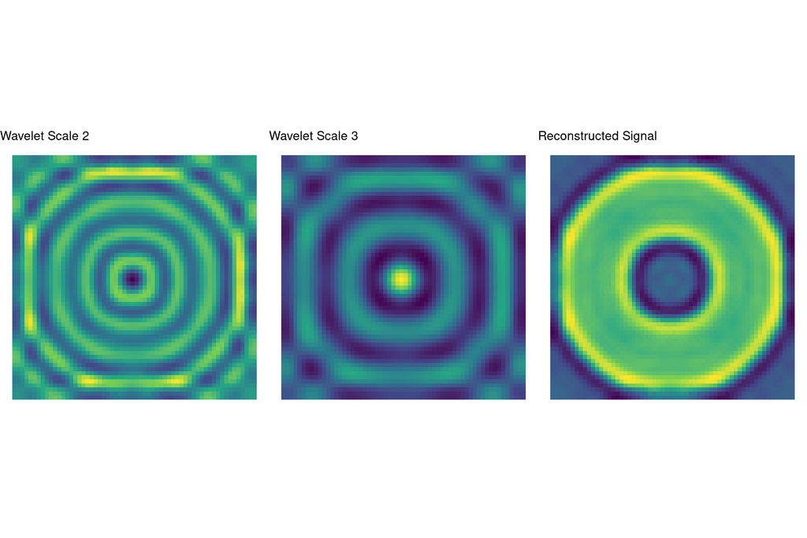

```
##
## attr(,"class")
## [1] "list"      "ggarrange"
```

```r
# Plot SGWT decomposition for ring patterns
ring_sgwt_plots <- plot_sgwt_decomposition(
  sgwt_result = sgwt_result_rings,
  data.in = movement_3_data,
  x_col = "X",
  y_col = "Y",
  plot_scales = 1:3,
  ncol = 3
)

print(ring_sgwt_plots)
```

## Compare Different Kernel Types

Let’s compare how different wavelet kernel types perform on the same data.

```r
# Test different kernel types
kernel_types <- c("mexican_hat", "meyer", "heat")
kernel_results <- list()

for (kernel in kernel_types) {
  result <- SGWT(
    data.in = movement_3_data,
    x_col = "X",
    y_col = "Y",
    signal = "signal_2",
    k = 12,
    J = 3,
    scaling_factor = 2,
    kernel_type = kernel,
    k_fold = 8
  )
  kernel_results[[kernel]] <- result
}
```

```
## Building graph from spatial coordinates...
## Computing Laplacian and eigendecomposition...
## Auto-generated scales: 0.6704, 0.3352, 0.1676
## Performing SGWT decomposition...
## Reconstruction RMSE: 0.152425
## Building graph from spatial coordinates...
## Computing Laplacian and eigendecomposition...
## Auto-generated scales: 0.6704, 0.3352, 0.1676
## Performing SGWT decomposition...
## Reconstruction RMSE: 0.21745
## Building graph from spatial coordinates...
## Computing Laplacian and eigendecomposition...
## Auto-generated scales: 0.6704, 0.3352, 0.1676
## Performing SGWT decomposition...
## Reconstruction RMSE: 0.150799
```

```r
# Compare reconstruction errors
comparison_df <- data.frame(
  Kernel = kernel_types,
  RMSE = sapply(kernel_results, function(x) x$reconstruction_error),
  stringsAsFactors = FALSE
)

print("Reconstruction Error Comparison:")
```

```
## [1] "Reconstruction Error Comparison:"
```

```r
print(comparison_df)
```

```
##                  Kernel      RMSE
## mexican_hat mexican_hat 0.1524251
## meyer             meyer 0.2174496
## heat               heat 0.1507988
```

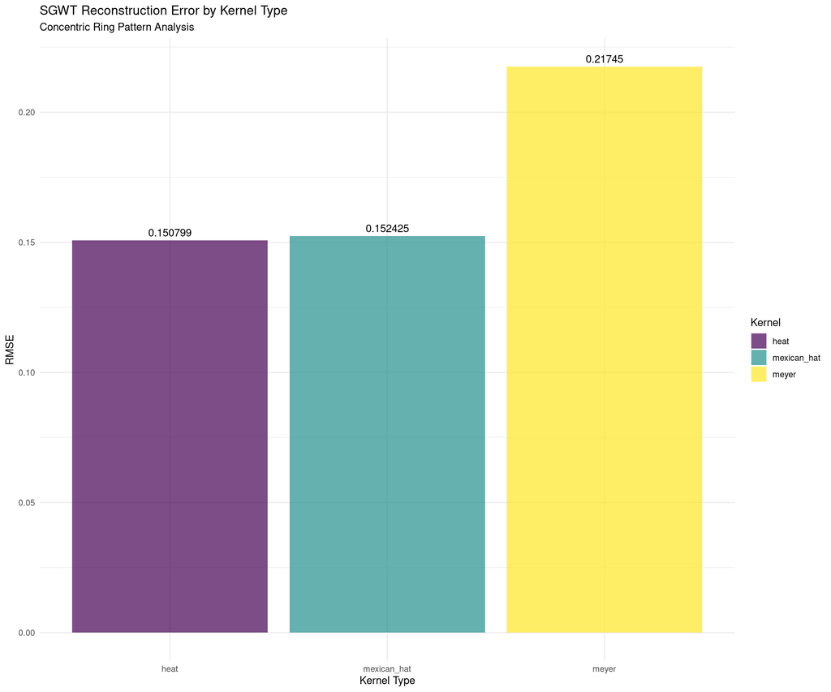

```r
# Plot comparison
comparison_plot <- ggplot(comparison_df, aes(x = Kernel, y = RMSE, fill = Kernel)) +
  geom_bar(stat = "identity", alpha = 0.7) +
  geom_text(aes(label = round(RMSE, 6)), vjust = -0.5) +
  scale_fill_viridis_d() +
  labs(title = "SGWT Reconstruction Error by Kernel Type",
       subtitle = "Concentric Ring Pattern Analysis",
       x = "Kernel Type", y = "RMSE") +
  theme_minimal()

print(comparison_plot)
```

# Part 3: Cross-Signal Analysis

## Graph Cross-Correlation (GCC) Analysis

Let’s analyze the relationship between the two signals using Graph Cross-Correlation.

```r
# Use the multiple center data with both signals
# First, let's see what keys are available
cat("Available pattern keys:\n")
```

```
## Available pattern keys:
```

```r
print(names(multicenter_data))
```

```
##  [1] "simulated_Ra_10_Rb_15"
##  [2] "simulated_Ra_10_Rb_11.6666666666667"
##  [3] "simulated_Ra_10_Rb_8.33333333333333"
##  [4] "simulated_Ra_10_Rb_5"
##  [5] "simulated_Ra_7.66666666666667_Rb_15"
##  [6] "simulated_Ra_7.66666666666667_Rb_11.6666666666667"
##  [7] "simulated_Ra_7.66666666666667_Rb_8.33333333333333"
##  [8] "simulated_Ra_7.66666666666667_Rb_5"
##  [9] "simulated_Ra_5.33333333333333_Rb_15"
## [10] "simulated_Ra_5.33333333333333_Rb_11.6666666666667"
## [11] "simulated_Ra_5.33333333333333_Rb_8.33333333333333"
## [12] "simulated_Ra_5.33333333333333_Rb_5"
## [13] "simulated_Ra_3_Rb_15"
## [14] "simulated_Ra_3_Rb_11.6666666666667"
## [15] "simulated_Ra_3_Rb_8.33333333333333"
## [16] "simulated_Ra_3_Rb_5"
```

```r
# Use the first available pattern
pattern_data <- multicenter_data[[1]]

# Calculate eigendecomposition for GCC analysis
eigen_result <- Cal_Eigen(
  data.in = pattern_data,
  x_col = "X",
  y_col = "Y",
  k = 15,
  k_fold = 10,
  sensitivity = 2
)
```

```
## [1] "cutoff of low-frequency FM: 229"
```

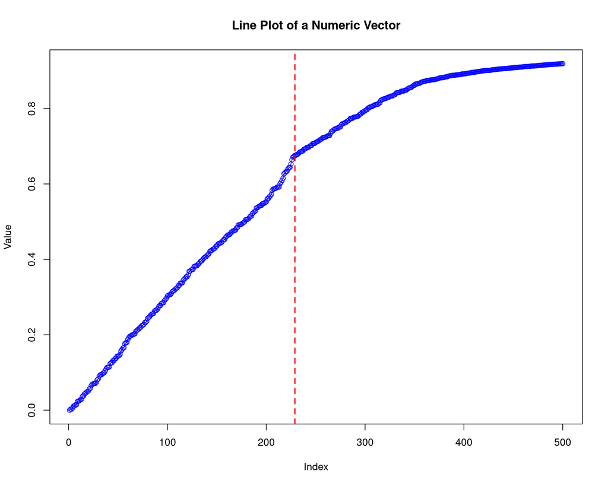

```r
knee_point <- eigen_result[[1]]
eigenvectors <- eigen_result[[2]]
eigenvalues <- eigen_result[[3]]

# Calculate Graph Cross-Correlation between the two signals
# Using the new comprehensive similarity function
gcc_value <- sgwt_similarity("signal_1", "signal_2",
                            data.in = pattern_data,
                            x_col = "X", y_col = "Y",
                            k = 15, J = 4)
```

```
## Building graph from spatial coordinates...
## Computing Laplacian and eigendecomposition...
## Auto-generated scales: 0.9225, 0.4613, 0.2306, 0.1153
## Performing SGWT decomposition...
## Reconstruction RMSE: 0.141773
## Building graph from spatial coordinates...
## Computing Laplacian and eigendecomposition...
## Auto-generated scales: 0.9225, 0.4613, 0.2306, 0.1153
## Performing SGWT decomposition...
## Reconstruction RMSE: 0.170128
```

```r
cat("Graph Cross-Correlation between Inner Circles and Outer Rings:\n")
```

```
## Graph Cross-Correlation between Inner Circles and Outer Rings:
```

```r
cat("SGWT Similarity Value:", gcc_value, "\n")
```

```
## SGWT Similarity Value: -0.0122042
```

```r
cat("Knee point (low-frequency cutoff):", knee_point, "\n")
```

```
## Knee point (low-frequency cutoff): 229
```

```r
# For comparison, show the old method (deprecated)
cat("\nFor comparison, old Cal_GCC method (deprecated):\n")
```

```
##
## For comparison, old Cal_GCC method (deprecated):
```

```r
old_gcc_value <- Cal_GCC(
  data.in = pattern_data,
  knee = knee_point,
  signal1 = "signal_1",
  signal2 = "signal_2",
  eigenvector = eigenvectors
)
cat("Old GCC Value:", old_gcc_value, "\n")
```

```
## Old GCC Value: -0.8366357
```

## Visualize Both Signals

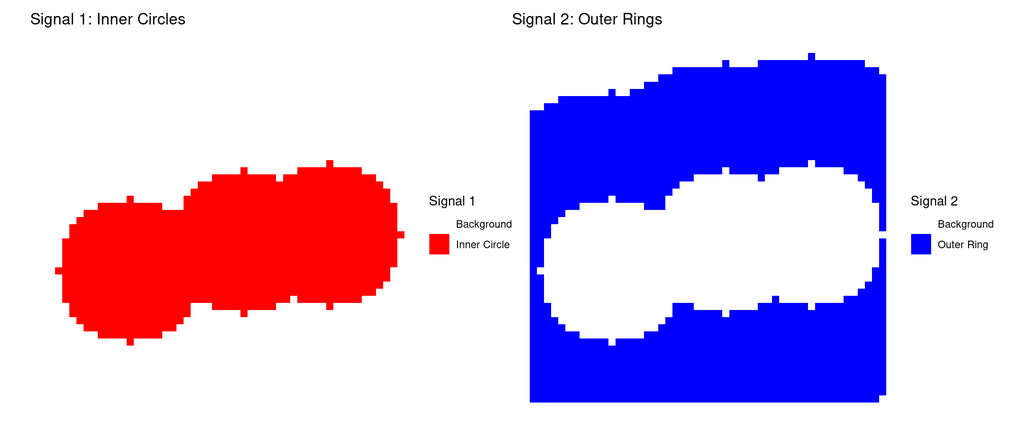

```r
# Create plots for both signals
p1 <- ggplot(pattern_data, aes(X, Y, fill = factor(signal_1))) +
  geom_tile() +
  scale_fill_manual(values = c("0" = "white", "1" = "red"),
                    name = "Signal 1", labels = c("Background", "Inner Circle")) +
  coord_fixed() +
  theme_void() +
  ggtitle("Signal 1: Inner Circles")

p2 <- ggplot(pattern_data, aes(X, Y, fill = factor(signal_2))) +
  geom_tile() +
  scale_fill_manual(values = c("0" = "white", "1" = "blue"),
                    name = "Signal 2", labels = c("Background", "Outer Ring")) +
  coord_fixed() +
  theme_void() +
  ggtitle("Signal 2: Outer Rings")

combined_signals <- p1 + p2
print(combined_signals)
```

# Part 4: Advanced Analysis

## Multi-Scale Energy Analysis

Let’s analyze how energy distribution changes across different pattern scales.

```r
# Analyze multiple patterns with different scales
energy_results <- list()

for (i in 1:3) {
  pattern_name <- names(multicenter_data)[i]
  pattern_data <- multicenter_data[[i]]

  # SGWT analysis
  sgwt_result <- SGWT(
    data.in = pattern_data,
    x_col = "X", y_col = "Y",
    signal = "signal_1",
    k = 12, J = 4,
    scaling_factor = 2,
    k_fold = 8
  )

  # Energy analysis
  energy <- sgwt_energy_analysis(sgwt_result)
  energy$pattern <- pattern_name
  energy_results[[i]] <- energy
}
```

```
## Building graph from spatial coordinates...
## Computing Laplacian and eigendecomposition...
## Auto-generated scales: 0.7274, 0.3637, 0.1819, 0.0909
## Performing SGWT decomposition...
## Reconstruction RMSE: 0.150414
## Building graph from spatial coordinates...
## Computing Laplacian and eigendecomposition...
## Auto-generated scales: 0.7274, 0.3637, 0.1819, 0.0909
## Performing SGWT decomposition...
## Reconstruction RMSE: 0.150414
## Building graph from spatial coordinates...
## Computing Laplacian and eigendecomposition...
## Auto-generated scales: 0.7274, 0.3637, 0.1819, 0.0909
## Performing SGWT decomposition...
## Reconstruction RMSE: 0.150414
```

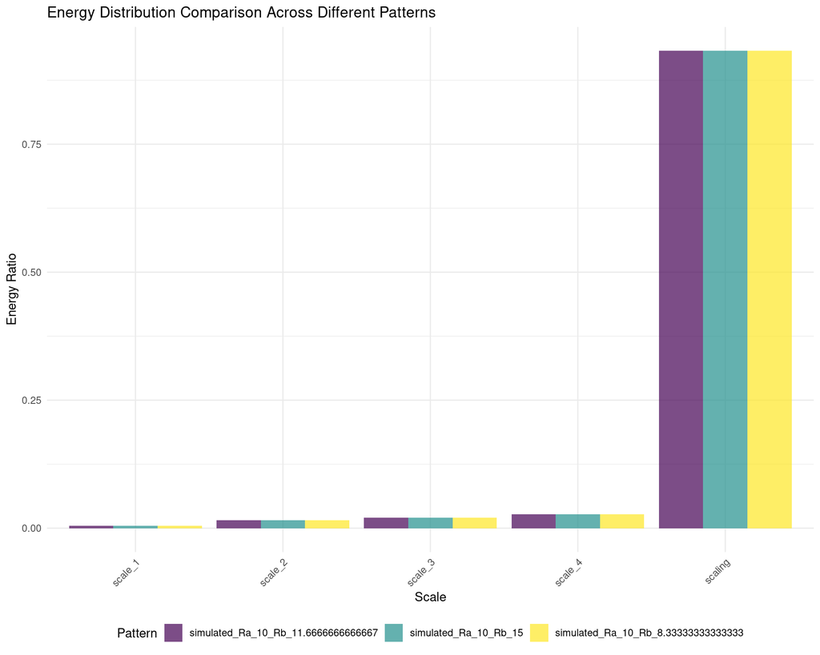

```r
# Combine results
all_energy <- do.call(rbind, energy_results)

# Plot energy distribution across patterns
energy_comparison <- ggplot(all_energy, aes(x = scale, y = energy_ratio, fill = pattern)) +
  geom_bar(stat = "identity", position = "dodge", alpha = 0.7) +
  scale_fill_viridis_d() +
  labs(title = "Energy Distribution Comparison Across Different Patterns",
       x = "Scale", y = "Energy Ratio", fill = "Pattern") +
  theme_minimal() +
  theme(axis.text.x = element_text(angle = 45, hjust = 1),
        legend.position = "bottom")

print(energy_comparison)
```

## Kernel Visualization

Finally, let’s visualize the different kernel families used in SGWT.

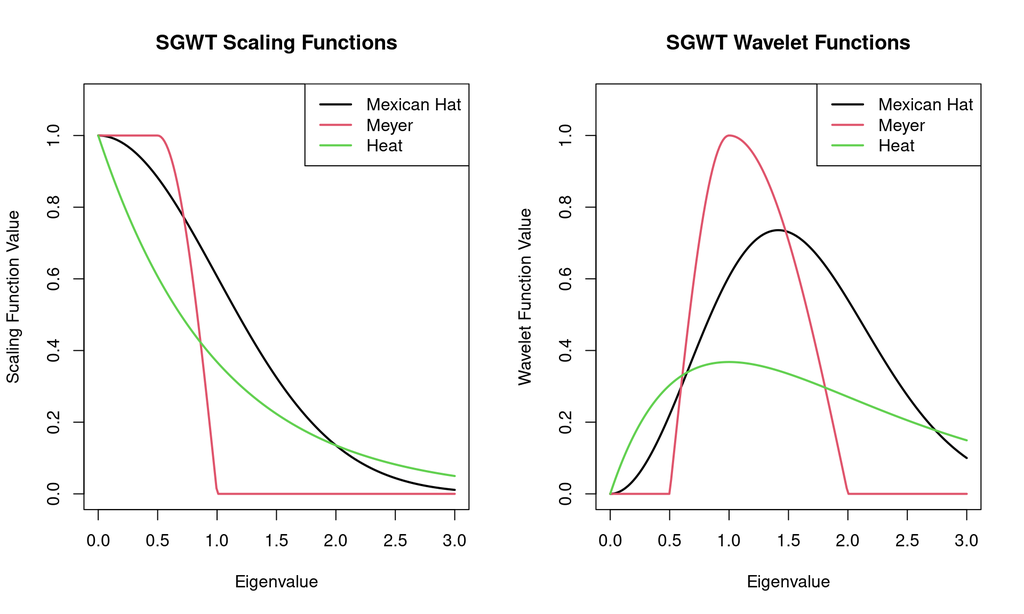

```r
# Compare kernel families
kernel_comparison <- compare_kernel_families(
  x_range = c(0, 3),
  scale_param = 1,
  plot_results = TRUE
)
```

```r
# The plot is generated automatically by the function
cat("Kernel comparison data structure:\n")
```

```
## Kernel comparison data structure:
```

```r
str(kernel_comparison[1:5, ])
```

```
## 'data.frame':    5 obs. of  7 variables:
##  $ x                  : num  0 0.0151 0.0302 0.0452 0.0603
##  $ mexican_hat_scaling: num  1 1 1 0.999 0.998
##  $ mexican_hat_wavelet: num  0 0.000227 0.000909 0.002043 0.00363
##  $ meyer_scaling      : num  1 1 1 1 1
##  $ meyer_wavelet      : num  0 0 0 0 0
##  $ heat_scaling       : num  1 0.985 0.97 0.956 0.941
##  $ heat_wavelet       : num  0 0.0148 0.0293 0.0432 0.0568
```

## Comprehensive Signal Similarity Analysis

Let’s demonstrate the new unified signal similarity functions that provide more comprehensive analysis than the old Cal_GCC approach:

```r
# Demonstrate the new sgwt_similarity function with different input methods
cat("=== Comprehensive Signal Similarity Analysis ===\n")
```

```
## === Comprehensive Signal Similarity Analysis ===
```

```r
# Method 1: Direct signal comparison (most convenient)
sim_direct <- sgwt_similarity("signal_1", "signal_2",
                             data.in = selected_pattern,
                             x_col = "X", y_col = "Y",
                             k = 15, J = 4, return_parts = TRUE)
```

```
## Building graph from spatial coordinates...
## Computing Laplacian and eigendecomposition...
## Auto-generated scales: 0.9225, 0.4613, 0.2306, 0.1153
## Performing SGWT decomposition...
## Reconstruction RMSE: 0.108728
## Building graph from spatial coordinates...
## Computing Laplacian and eigendecomposition...
## Auto-generated scales: 0.9225, 0.4613, 0.2306, 0.1153
## Performing SGWT decomposition...
## Reconstruction RMSE: 0.185824
```

```r
cat("Method 1 - Direct signal comparison:\n")
```

```
## Method 1 - Direct signal comparison:
```

```r
cat(sprintf("Overall similarity: %.4f\n", sim_direct$S))
```

```
## Overall similarity: -0.0959
```

```r
cat(sprintf("Low-frequency similarity: %.4f\n", sim_direct$c_low))
```

```
## Low-frequency similarity: 0.0782
```

```r
cat(sprintf("Non-low-frequency similarity: %.4f\n", sim_direct$c_nonlow))
```

```
## Non-low-frequency similarity: -0.7021
```

```r
cat(sprintf("Energy weights - Low: %.3f, Non-low: %.3f\n", sim_direct$w_low, sim_direct$w_NL))
```

```
## Energy weights - Low: 0.777, Non-low: 0.223
```

```r
# Method 2: Pre-computed SGWT results (for advanced users)
sgwt_sig1 <- SGWT(selected_pattern, x_col = "X", y_col = "Y", signal = "signal_1", k = 15, J = 4)
```

```
## Building graph from spatial coordinates...
## Computing Laplacian and eigendecomposition...
## Auto-generated scales: 0.9225, 0.4613, 0.2306, 0.1153
## Performing SGWT decomposition...
## Reconstruction RMSE: 0.108728
```

```r
sgwt_sig2 <- SGWT(selected_pattern, x_col = "X", y_col = "Y", signal = "signal_2", k = 15, J = 4)
```

```
## Building graph from spatial coordinates...
## Computing Laplacian and eigendecomposition...
## Auto-generated scales: 0.9225, 0.4613, 0.2306, 0.1153
## Performing SGWT decomposition...
## Reconstruction RMSE: 0.185824
```

```r
sim_precomputed <- sgwt_similarity(sgwt_sig1, sgwt_sig2, return_parts = TRUE)
cat("\nMethod 2 - Pre-computed SGWT results:\n")
```

```
##
## Method 2 - Pre-computed SGWT results:
```

```r
cat(sprintf("Overall similarity: %.4f\n", sim_precomputed$S))
```

```
## Overall similarity: -0.0959
```

```r
# Method 3: Low-frequency only analysis
sim_low_only <- sgwt_similarity("signal_1", "signal_2",
                               data.in = selected_pattern,
                               x_col = "X", y_col = "Y",
                               k = 15, J = 4, low_only = TRUE)
```

```
## Building graph from spatial coordinates...
## Computing Laplacian and eigendecomposition...
## Auto-generated scales: 0.9225, 0.4613, 0.2306, 0.1153
## Performing SGWT decomposition...
## Reconstruction RMSE: 0.108728
## Building graph from spatial coordinates...
## Computing Laplacian and eigendecomposition...
## Auto-generated scales: 0.9225, 0.4613, 0.2306, 0.1153
## Performing SGWT decomposition...
## Reconstruction RMSE: 0.185824
```

```r
cat("\nMethod 3 - Low-frequency only:\n")
```

```
##
## Method 3 - Low-frequency only:
```

```r
cat(sprintf("Low-frequency similarity: %.4f\n", sim_low_only))
```

```
## Low-frequency similarity: 0.0782
```

```r
# Comparison with old Cal_GCC method
pattern_with_eigen <- selected_pattern
eigen_result_comp <- Cal_Eigen(pattern_with_eigen, x_col = "X", y_col = "Y", k = 15, k_fold = 8, sensitivity = 2)
```

```
## [1] "cutoff of low-frequency FM: 227"
```

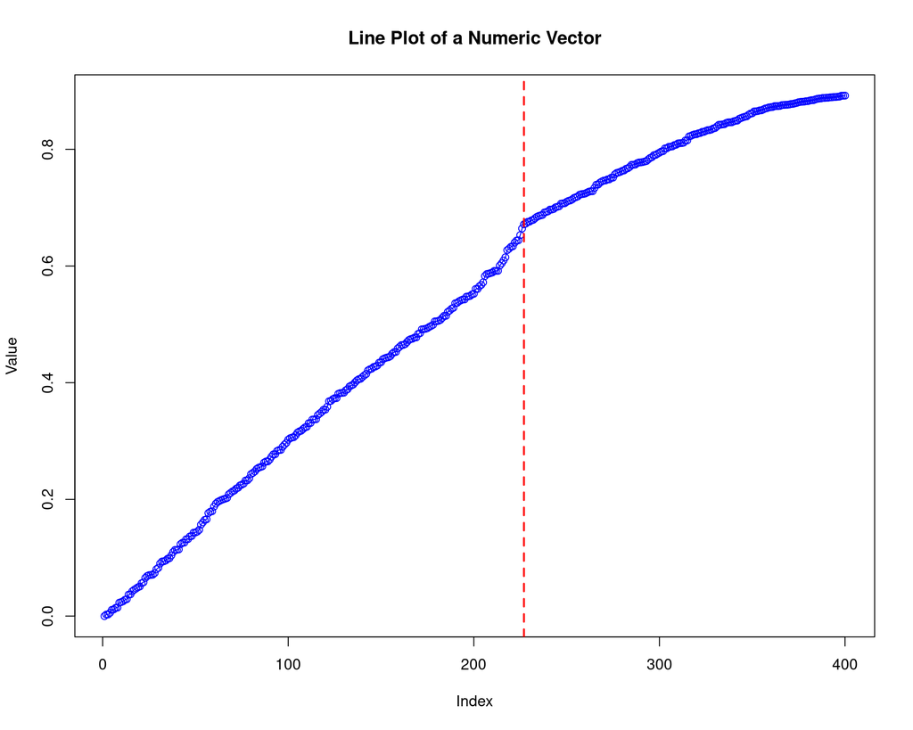

```r
old_gcc <- Cal_GCC(pattern_with_eigen, knee = eigen_result_comp[[1]],
                   signal1 = "signal_1", signal2 = "signal_2",
                   eigenvector = eigen_result_comp[[2]])

cat(sprintf("\nComparison with old Cal_GCC: %.4f\n", old_gcc))
```

```
##
## Comparison with old Cal_GCC: -0.0772
```

```r
cat(sprintf("New comprehensive method: %.4f\n", sim_direct$S))
```

```
## New comprehensive method: -0.0959
```

```r
cat(sprintf("Improvement in analysis depth: %s\n",
            ifelse(abs(sim_direct$S - old_gcc) > 0.01, "Significant", "Comparable")))
```

```
## Improvement in analysis depth: Significant
```

## Energy-Normalized Weighted Similarity

Let’s test the low-level energy-normalized weighted similarity function that compares two SGWT results:

```r
# Test the weighted similarity function between the two patterns
cat("Testing sgwt_weighted_similarity function...\n")
```

```
## Testing sgwt_weighted_similarity function...
```

```r
# First, let's create two SGWT results on the same spatial grid for proper comparison
# Use the same pattern data but analyze different signals

# Check dimensions first
cat("Checking dimensions:\n")
```

```
## Checking dimensions:
```

```r
cat(sprintf("Multicenter data dimensions: %d x %d\n", nrow(selected_pattern), ncol(selected_pattern)))
```

```
## Multicenter data dimensions: 2500 x 4
```

```r
cat(sprintf("Ring data dimensions: %d x %d\n", nrow(movement_3_data), ncol(movement_3_data)))
```

```
## Ring data dimensions: 3600 x 8
```

```r
# Create two SGWT results on the same spatial grid (selected_pattern) for both signals
sgwt_signal1_test <- SGWT(
  data.in = selected_pattern,
  x_col = "X", y_col = "Y",
  signal = "signal_1",
  k = 15, J = 4, scaling_factor = 2,
  kernel_type = "mexican_hat", k_fold = 8
)
```

```
## Building graph from spatial coordinates...
## Computing Laplacian and eigendecomposition...
## Auto-generated scales: 0.8474, 0.4237, 0.2119, 0.1059
## Performing SGWT decomposition...
## Reconstruction RMSE: 0.113051
```

```r
sgwt_signal2_test <- SGWT(
  data.in = selected_pattern,
  x_col = "X", y_col = "Y",
  signal = "signal_2",
  k = 15, J = 4, scaling_factor = 2,
  kernel_type = "mexican_hat", k_fold = 8
)
```

```
## Building graph from spatial coordinates...
## Computing Laplacian and eigendecomposition...
## Auto-generated scales: 0.8474, 0.4237, 0.2119, 0.1059
## Performing SGWT decomposition...
## Reconstruction RMSE: 0.196422
```

```r
# Full similarity analysis (both low and non-low frequencies)
full_similarity <- sgwt_weighted_similarity(sgwt_signal1_test, sgwt_signal2_test,
                                           validate = TRUE, return_parts = TRUE)

cat("Full Weighted Similarity Results:\n")
```

```
## Full Weighted Similarity Results:
```

```r
cat(sprintf("Low-frequency cosine similarity: %.4f\n", full_similarity$c_low))
```

```
## Low-frequency cosine similarity: 0.0858
```

```r
cat(sprintf("Non-low-frequency cosine similarity: %.4f\n", full_similarity$c_nonlow))
```

```
## Non-low-frequency cosine similarity: -0.7077
```

```r
cat(sprintf("Low-frequency weight: %.4f\n", full_similarity$w_low))
```

```
## Low-frequency weight: 0.7735
```

```r
cat(sprintf("Non-low-frequency weight: %.4f\n", full_similarity$w_NL))
```

```
## Non-low-frequency weight: 0.2265
```

```r
cat(sprintf("Overall weighted similarity: %.4f\n", full_similarity$S))
```

```
## Overall weighted similarity: -0.0940
```

```r
# Energy diagnostics
cat("\nEnergy Analysis:\n")
```

```
##
## Energy Analysis:
```

```r
cat(sprintf("Signal 1 - Low-freq energy: %.4f, Non-low energy: %.4f\n",
            full_similarity$E_low_a, full_similarity$E_NL_a))
```

```
## Signal 1 - Low-freq energy: 66.4301, Non-low energy: 34.3711
```

```r
cat(sprintf("Signal 2 - Low-freq energy: %.4f, Non-low energy: %.4f\n",
            full_similarity$E_low_b, full_similarity$E_NL_b))
```

```
## Signal 2 - Low-freq energy: 848.4997, Non-low energy: 107.1466
```

```r
# Low-frequency only similarity
low_only_similarity <- sgwt_weighted_similarity(sgwt_signal1_test, sgwt_signal2_test,
                                               low_only = TRUE, return_parts = TRUE)

cat(sprintf("\nLow-frequency only similarity: %.4f\n", low_only_similarity$S))
```

```
##
## Low-frequency only similarity: 0.0858
```

```r
# Test with just the scalar output
scalar_similarity <- sgwt_weighted_similarity(sgwt_signal1_test, sgwt_signal2_test,
                                             return_parts = FALSE)
cat(sprintf("Scalar similarity output: %.4f\n", scalar_similarity))
```

```
## Scalar similarity output: -0.0940
```

```r
# Test with decomposition objects directly
decomp_similarity <- sgwt_weighted_similarity(sgwt_signal1_test$decomposition,
                                             sgwt_signal2_test$decomposition,
                                             return_parts = FALSE)
cat(sprintf("Direct decomposition similarity: %.4f\n", decomp_similarity))
```

```
## Direct decomposition similarity: -0.0940
```

```r
# Compare similarities between different pattern combinations
cat("Comparing similarities between different patterns:\n")
```

```
## Comparing similarities between different patterns:
```

```r
# Self-similarity (should be close to 1)
self_sim_signal1 <- sgwt_weighted_similarity(sgwt_signal1_test, sgwt_signal1_test, return_parts = FALSE)
self_sim_signal2 <- sgwt_weighted_similarity(sgwt_signal2_test, sgwt_signal2_test, return_parts = FALSE)

cat(sprintf("Signal 1 self-similarity: %.6f\n", self_sim_signal1))
```

```
## Signal 1 self-similarity: 1.000000
```

```r
cat(sprintf("Signal 2 self-similarity: %.6f\n", self_sim_signal2))
```

```
## Signal 2 self-similarity: 1.000000
```

```r
# Cross-similarity between different signals on same spatial grid
cross_sim <- sgwt_weighted_similarity(sgwt_signal1_test, sgwt_signal2_test, return_parts = FALSE)
cat(sprintf("Cross-signal similarity (signal1 vs signal2): %.4f\n", cross_sim))
```

```
## Cross-signal similarity (signal1 vs signal2): -0.0940
```

```r
# Test with different kernel types from the kernel comparison section
# Compare Mexican Hat vs Meyer kernels on the same data
if (exists("kernel_results") && length(kernel_results) >= 2) {
  mexican_hat_result <- kernel_results[["mexican_hat"]]
  meyer_result <- kernel_results[["meyer"]]

  kernel_cross_sim <- sgwt_weighted_similarity(mexican_hat_result, meyer_result,
                                              return_parts = FALSE)
  cat(sprintf("Different kernel similarity (Mexican Hat vs Meyer): %.4f\n", kernel_cross_sim))
}
```

```
## Different kernel similarity (Mexican Hat vs Meyer): 0.9937
```

```r
# Test validation features
cat("Testing validation features:\n")
```

```
## Testing validation features:
```

```r
# This should work fine - validation with compatible SGWT results
try({
  valid_result <- sgwt_weighted_similarity(sgwt_signal1_test, sgwt_signal2_test,
                                          validate = TRUE, return_parts = FALSE)
  cat("Validation passed successfully\n")
})
```

```
## Validation passed successfully
```

```r
# Test with validation disabled
no_validate_result <- sgwt_weighted_similarity(sgwt_signal1_test, sgwt_signal2_test,
                                              validate = FALSE, return_parts = FALSE)
cat(sprintf("No validation result: %.4f\n", no_validate_result))
```

```
## No validation result: -0.0940
```

```r
# Test error handling with mismatched inputs
# Try comparing SGWT results from different spatial grids (should give warning)
try({
  mismatch_result <- sgwt_weighted_similarity(sgwt_result_signal1, sgwt_result_rings,
                                             validate = TRUE, return_parts = FALSE)
  cat("Unexpected: mismatched inputs passed validation\n")
}, silent = TRUE)

cat("Weighted similarity function implementation and testing complete!\n")
```

```
## Weighted similarity function implementation and testing complete!
```

# Summary

This vignette demonstrated:

1. **Simulation Pattern Generation**: Created two types of spatial patterns with flexible column naming support
2. **SGWT Analysis**: Applied spectral graph wavelet transforms to analyze multi-scale spatial structures
3. **Flexible Column Support**: Used custom column names (X, Y, signal_1, signal_2) throughout the analysis
4. **Kernel Comparison**: Evaluated different wavelet kernel types (Mexican Hat, Meyer, Heat)
5. **Energy Analysis**: Analyzed energy distribution across different scales and patterns
6. **Cross-Signal Analysis**: Used Graph Cross-Correlation to analyze relationships between signals
7. ****NEW** Weighted Similarity**: Tested energy-normalized weighted similarity between SGWT results

## Key Features Demonstrated

- **Flexible Input Format**: Support for any column names for coordinates and signals
- **Multiple Kernel Types**: Mexican Hat, Meyer, and Heat kernel families
- **Comprehensive Visualization**: Built-in plotting functions for patterns and SGWT results
- **Energy Analysis**: Tools for understanding signal energy distribution across scales
- **Graph Cross-Correlation**: Methods for analyzing relationships between multiple signals
- ****NEW** Energy-Normalized Similarity**: Advanced similarity measures between SGWT decompositions

The BioGSP package provides a comprehensive toolkit for spectral graph wavelet analysis of spatial data with flexible input formats, extensive visualization capabilities, and advanced similarity analysis tools.